# WordPredictor Pitch

December 9, 2019

## Summary

### *Goal*

- An algorithm that predicts the final word in a string of words, providing 3-5 potential predictions
- Intended for deployment in cellphones, internet browsers and similar technology

### *Approach*

- [Stupid Backoff algorithm](https://www.aclweb.org/anthology/D07-1090.pdf) coded in R

## WordPredictor App

### *Try the app at https://bit.ly/36qU1uz*

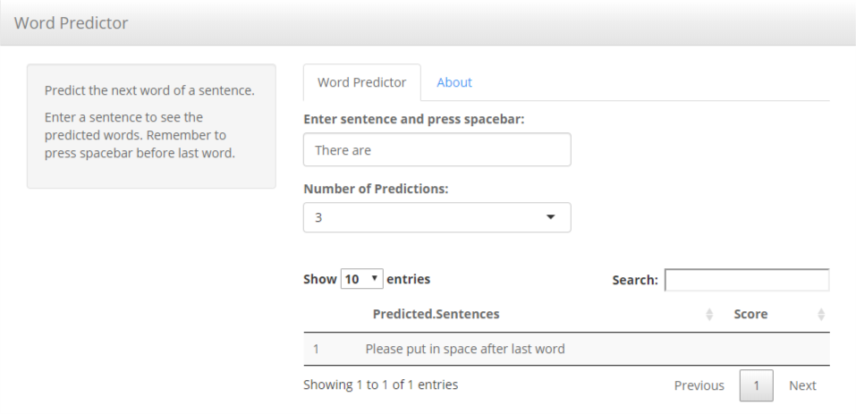

- Put the phrase in the text box and press spacebar
- Select the number of predictions from the drop-down box
- The app will return the top predictions

## Approach

### *Stupid Backoff Algorithm*

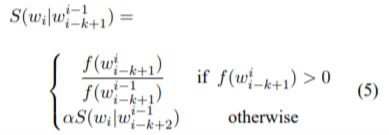

- [A recursive algorithm](https://www.aclweb.org/anthology/D07-1090.pdf) that increases the score of longer phrases to prioritize context over raw frequency of words
- The weighting is represented by \(\alpha\) - trail and error determined 0.15 was optimal weighting

### *Corpus*

- [The Swiftkey corpus](https://d396qusza40orc.cloudfront.net/dsscapstone/dataset/Coursera-SwiftKey.zip) was further complemented with additional corpi - [Partial collection of Gutenberg Project corpus](https://web.eecs.umich.edu/~lahiri/gutenberg_dataset.html) and [Large Movie Review Dataset](https://ai.stanford.edu/~amaas/data/sentiment/).

## Performance

- The algorithm performance was quantified using an R-script benchmark.R from dsci-benchmark which tested the algorithm against a set of training data

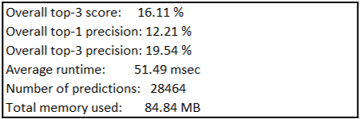

- The app performed similar to other apps built using Swiftkey corpus
- Different aspects were modified to improve model performance including alpha-weight, minimum frequency of phrases included in the inputted score-table and inclusion/exclusion of stop-words